# 20 years of Games

vh42720

November 28, 2017

## Introduction

[IGN dataset “20-years-of-games”](https://www.kaggle.com/egrinstein/20-years-of-games/data) is the collection of over 18000 games title throughout 2 decades (1996 - 2016). While the dataset has only 9 variables/features which is not suitable for predictive analysis, it offers us a way to take a snapshot of how games progress year after year. The main variables we will use in this long Exploratory Data Analysis are:

1. score: The score of the game title
2. score_phrase: Ordinal variable describing the score
3. title: title of the game
4. platform: name of the platform of the game
5. genre: genre of the game
6. release_year/month/day: the year, month, day the game was released respectively
7. system: a more compact representation of platform

## Loading libraries and dataset

```r
library(tidyverse)
library(ggplot2)
library(GGally)
library(ggthemes)
library(corrplot)
library(lubridate)
library(RColorBrewer)
library(gridExtra)
library(scales)
library(wordcloud)
library(ngram)
library(qdap)
library(tm)
```

## Reading in the data from ign.

```r
ign <- tbl_df(read.csv("ign.csv",stringsAsFactors = TRUE))
```

## Exploratory Data Analysis

```r
# Counting observations and overview of the dataset
dim(ign)
```

```
## [1] 18625    11
```

```r
str(ign)
```

```
## Classes 'tbl_df', 'tbl' and 'data.frame':    18625 obs. of  11 variables:
##  $ X             : int  0 1 2 3 4 5 6 7 8 9 ...
##  $ score_phrase  : Factor w/ 11 levels "Amazing","Awful",..: 1 1 6 6 6 5 2 1 2 5 ...
##  $ title         : Factor w/ 12589 levels "'Splosion Man",..: 5702 5703 9767 7249 7249 11406 2908 4446 2908 11406 ...
##  $ url           : Factor w/ 18577 levels "/games/0-d-beat-drop/xbox-360-14342395",..: 8390 8387 14319 10813 10812 16931 4271 6526 4270 16932 ...
##  $ platform      : Factor w/ 59 levels "Android","Arcade",..: 39 39 15 58 36 20 58 33 36 33 ...
##  $ score         : num  9 9 8.5 8.5 8.5 7 3 9 3 7 ...
##  $ genre         : Factor w/ 113 levels "","Action","Action, Adventure",..: 65 65 70 95 95 106 39 83 39 106 ...
##  $ editors_choice: Factor w/ 2 levels "N","Y": 2 2 1 1 1 1 1 2 1 1 ...
##  $ release_year  : int  2012 2012 2012 2012 2012 2012 2012 2012 2012 2012 ...
##  $ release_month : int  9 9 9 9 9 9 9 9 9 9 ...
##  $ release_day   : int  12 12 12 11 11 11 11 11 11 11 ...
```

```r
# Counting missing values
colSums(is.na(ign))
```

```
##              X   score_phrase          title            url       platform
##              0              0              0              0              0
##          score          genre editors_choice   release_year  release_month
##              0              0              0              0              0
##    release_day
##              0
```

```r
ign <- na.omit(ign)
```

X1 variable which is an index and url variable which is a website for the game can also be removed. To finish the cleaning process, we will transform score_phrase to factor. One unsual data point is te game released in 1970 which will be removed for most analysis but we will come back and play with it later.

```r
ign <- ign %>%
    select(-X, -url) %>%
    mutate(title = as.character(title)) %>%
    mutate(genre = factor(genre,
                          levels = names(sort(table(genre), decreasing=TRUE))))
```

## Genre Analysis

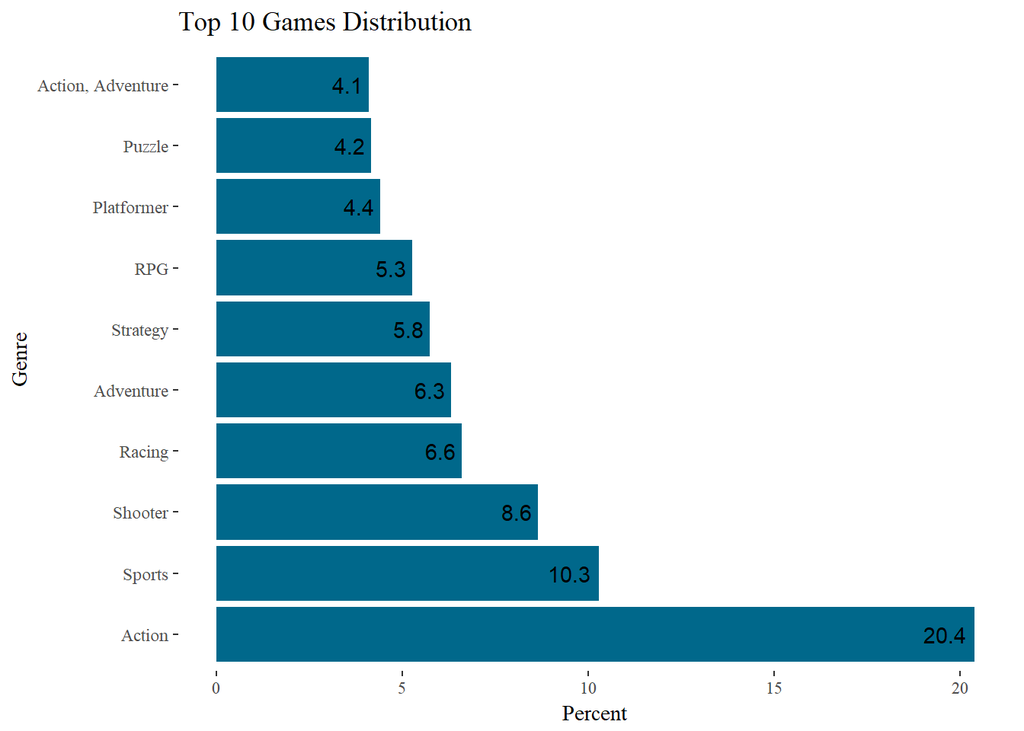

```r
top10 <- head(names((sort(table(ign$genre), decreasing = TRUE))), 10)

ign %>%
    filter(genre %in% top10) %>%
    group_by(genre) %>%
    summarize(percentage = n()/nrow(ign)) %>%
    ggplot(aes(x = genre, y = percentage * 100)) +
    geom_col(fill = "deepskyblue4") +
    coord_flip() +
    labs(x = "Genre", y = "Percent", title = "Top 10 Games Distribution") +
    theme_tufte() +
    geom_text(aes(label = round(percentage*100, digits = 1)), hjust = 1.2)
```

Unsurprisingly, Action genre is the predominant genre for gaming. Lets observe to see if this trend change over the year

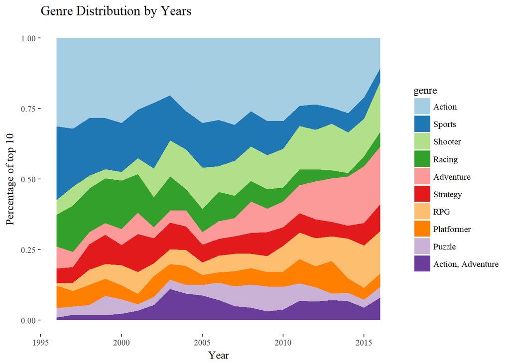

```r
ign %>%
    filter(genre %in% top10, release_year >= 1996) %>%
    group_by(genre, release_year) %>%
    summarize(count = n()) %>%
    ggplot(aes(x = release_year, y = count, group = genre, fill = genre)) +
    geom_area(position = "fill") + theme_tufte() + scale_fill_brewer(palette = "Paired") +
    labs(title = "Genre Distribution by Years", x = "Year", y = "Percentage of top 10")
```

Up until 2015, Action genre is dominating the gaming industry. However, Adventure Shooter, and RPG starts to take over around 2012. This trend can be explained with the release of various big titles in Adventure and RPG genre such as Call of Duty, The Witcher, Skyrim, Fallout, WOW expansions…The esport scene of Shooter games and wide spread of console are also correlated with this trend. (analysis below)

Notice that this is not a US only dataset hence Sport genre is not as popular. [US most popular](https://www.statista.com/statistics/189592/breakdown-of-us-video-game-sales-2009-by-genre/)

Now, lets take a look at how genre corellated to score.

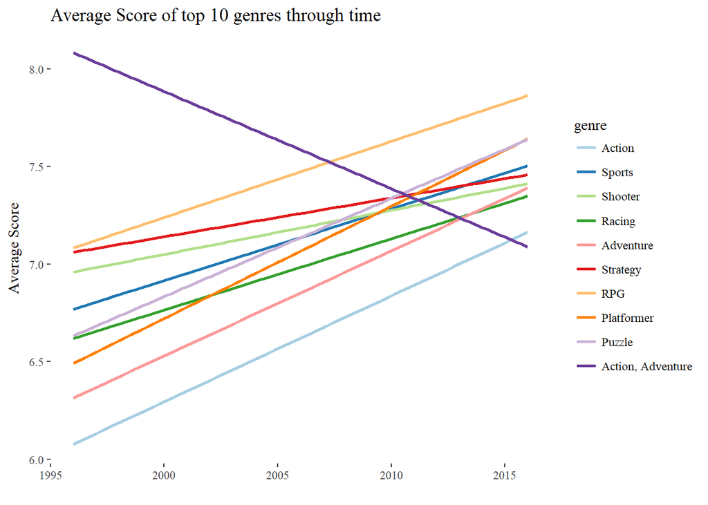

```r
ign %>%
    filter(genre %in% top10, release_year >= 1996) %>%
    group_by(genre, release_year) %>%
    summarize(average_score = mean(score, na.rm = TRUE)) %>%
    ggplot(aes(x = release_year, y = average_score, col = genre)) +
    geom_smooth(method = "lm", se = FALSE) +
    theme(axis.title.x = element_blank()) +
    theme_tufte() +
    labs(y = "Average Score", title = "Average Score of top 10 genres through time", x ="") +
    scale_color_brewer(palette = "Paired")
```

The plot is quite noisy due to big jumps in the rating year by year which suggests rating depends on the game title more than its genre. Nevertheless the data show that game ratings is increased slightly as a whole overtime except for Action, Adventure games whose rating keep declining!

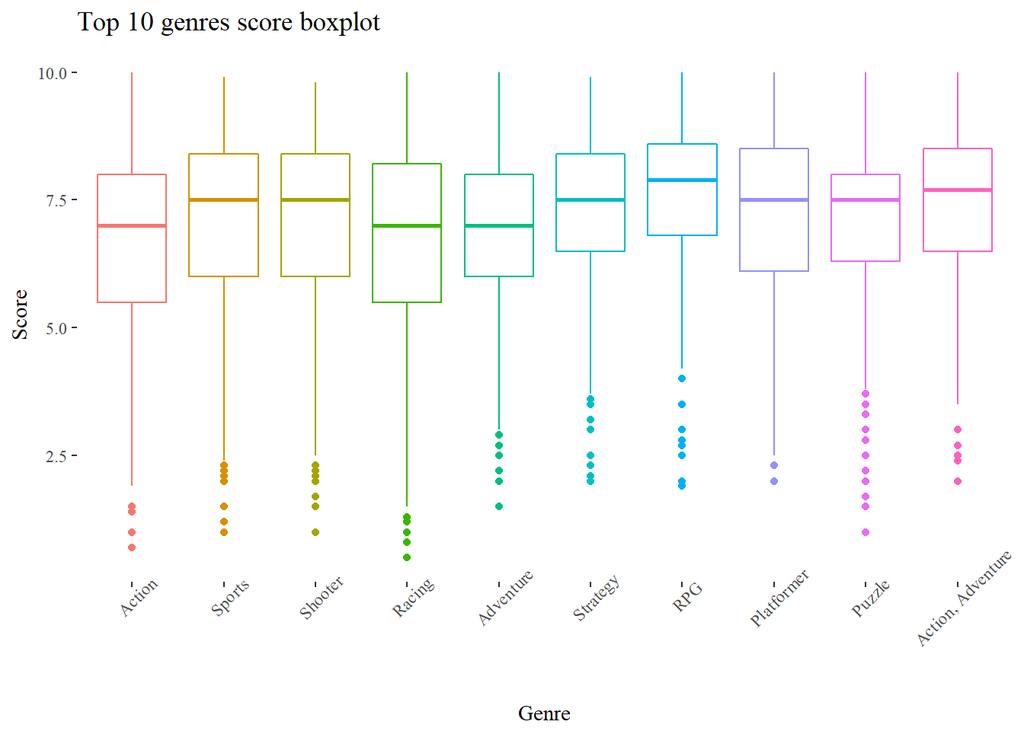

```r
ign %>%
    filter(genre %in% top10, release_year >= 1996) %>%
    ggplot(aes(x = genre, y = score, col = genre)) +
    geom_boxplot() +
    theme_tufte() +
    theme(legend.position = "none", axis.text.x = element_text(angle = 45)) +
    labs(title = "Top 10 genres score boxplot", y = "Score", x = "Genre")
```

#### Genre Conclusion

While gaming genre distribution is widely different, their rating is very similar. Perhaps platform will have a bigger impact on rating.

## Time Analysis

In this section, we will walk through various plots to show the effect of time on rating and release schedule. Since 11 categories of score_phrase are too overcrowded, we will reduce it into 5 groups: Masterpiece, Good, Okay, Bad and Disaster

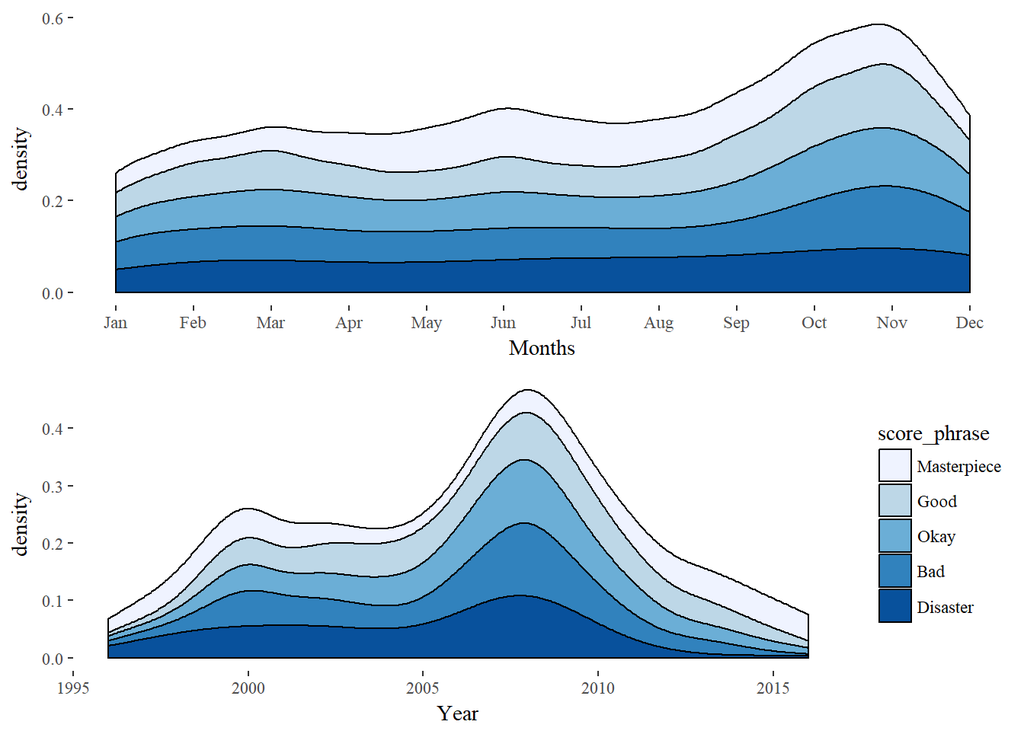

```r
library(plyr)
ign$score_phrase <- revalue(ign$score_phrase,
                            c("Amazing" = "Good", "Great" = "Good", "Mediocre" = "Okay",
                              "Awful" = "Bad", "Painful" = "Bad", "Unbearable" = "Disaster"))
ign$score_phrase <- factor(ign$score_phrase,
                           levels = c("Masterpiece", "Good", "Okay", "Bad", "Disaster"))
plot2 <- ign %>%
    filter(release_year >= 1996) %>%
    ggplot(aes(x = release_year, fill = score_phrase)) +
    geom_density(position = "stack") +
    scale_fill_brewer(palette = "Blues") +
    theme_tufte() +
    labs(x = "Year")
plot1 <- ign %>%
    filter(release_year >= 1996) %>%
    ggplot(aes(x = release_month, fill = score_phrase)) +
    geom_density(position = "stack") +
    scale_fill_brewer(palette = "Blues") +
    theme_tufte() +
    scale_x_continuous(breaks = 1:12, labels = month.abb) +
    theme(legend.position = "none") +
    labs(x = "Months")
grid.arrange(plot1, plot2)
```

The year 2008 saw a massive games titles releases. From then, it is slowly decreasing. However, we see that more masterpieces are being produced while bad and disaster games are becoming obsolete. This is a big change in the industry standard where only good games can survive (Does this have any correlation with EA buying game licenses?)

Also note the jump in game titles release in October, November. This jump can be explained by Fall holidays, back to school day…

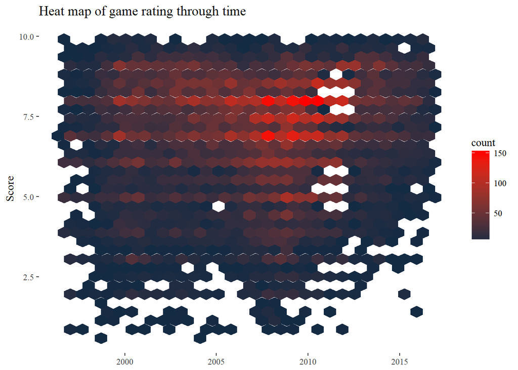

```r
detach("package:plyr", unload=TRUE)
ign %>%
    filter(release_year >= 1996) %>%
    unite("date", starts_with("release")) %>%
    mutate(date = ymd(date)) %>%
    ggplot(aes(x = date, y = score)) +
    stat_bin_hex() +
    scale_fill_gradient(high = "red", low = "#132B43") +
    theme_tufte() +
    theme(axis.title.x = element_blank()) +
    labs(title = "Heat map of game rating through time", y = "Score")
```

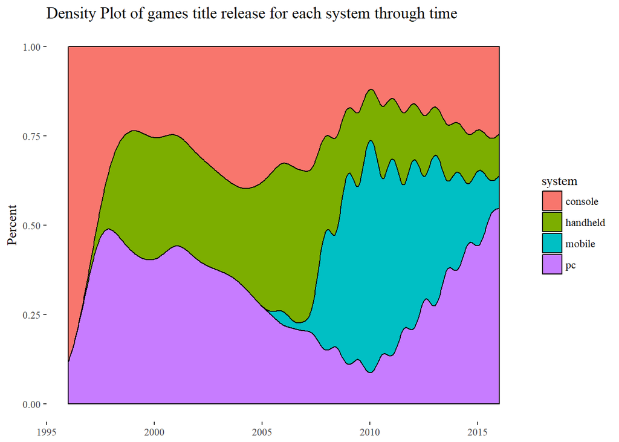

```r
hand_console <- c("PlayStation Vita", "Nintendo DS", "Nintendo 3DS",
                  "PlayStation Portable", "Lynx", "Game Boy", "Game Boy Color",
                  "NeoGeo Pocket Color", "Game.Com", "Dreamcast VMU", "WonderSwan",
                  "WonderSwan Color", "Game Boy Advance", "N-Gage", "Nintendo DSi",
                  "New Nintendo 3DS")
mobile <- c("iPad","iPhone", "Android", "iPod", "Windows Phone", "Windows Surface")
console <- c("Xbox 360", "PlayStation 3", "Wii", "PlayStation 4", "Wii U", "PlayStation",
             "Nintendo 64", "Saturn", "Dreamcast", "Arcade", "Nintendo 64DD",
             "PlayStation 2", "Xbox", "GameCube", "NES", "Genesis", "TurboGrafx-16",
             "Super NES", "NeoGeo", "Master System", "Atari 5200", "Atari 2600",
             "Sega 32X", "Vectrex", "Sega CD", "Xbox One", "Ouya", "Wireless")
pc <- c("Macintosh", "PC", "Linux", "DVD / HD Video Game", "Pocket PC", "TurboGrafx-CD",
        "Commodore 64/128", "Web Games", "SteamOS")

ign <- ign %>%
    mutate(system = ifelse(platform %in% hand_console, "handheld",
                           ifelse(platform %in% mobile, "mobile",
                                  ifelse(platform %in% console, "console", "pc"))))
ign$system <- as.factor(ign$system)
ign %>%
    filter(release_year >= 1996) %>%
    ggplot(aes(x = release_year, fill = system)) +
    geom_density(position = "fill") +
    theme_tufte() +
    theme(axis.title.x = element_blank()) +
    labs(title = "Density Plot of games title release for each system through time",
         y = "Percent")
```

Note that the game titles distribution across platform also correlated with its popularity (ie: more devs, more playerbase).[For more information](https://www.statista.com/chart/4527/game-developers-platform-preferences/) The rise and fall of many platforms are fascinating. We see the fall of PC and handheld for much of 2000 - 2010. This period also witnessed the rise of mobile game. It is no coincidence that smartphones and tablets are becoming widespread in this period also.

However, after 2010, PC rised and took over the gaming market. There are many factors contribute to this rise:

1. Esport by this time has reached a new height with the release of League of Legends.
2. Steams offered digital distribution of a massive library of indie game titles which in turn attract more devs.
3. Graphic cards’ prices were getting lower than ever.
4. Social media allowed people to share the experience.
5. Console took a massive amount of advertising to return the profit compare to the seasoned PC fan base.

Lastly, lets take a book at score distribution

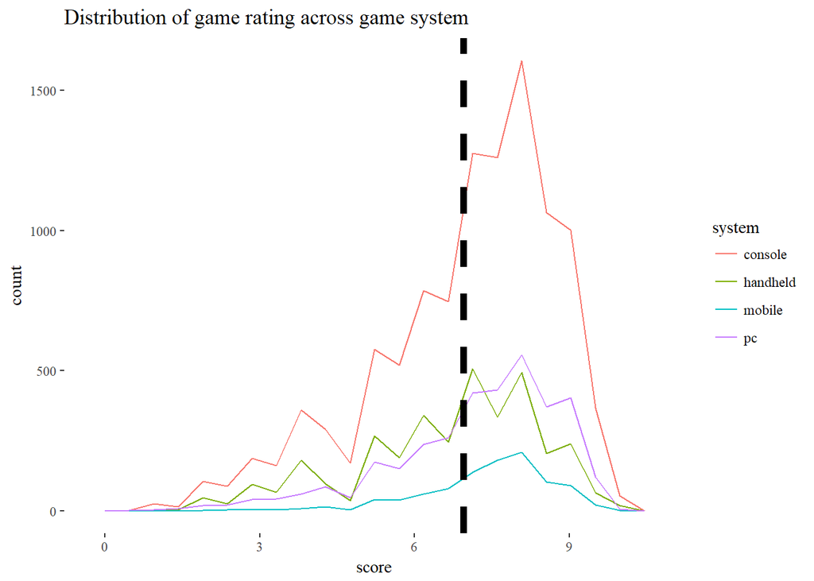

```r
ign %>%
    filter(release_year >= 1996) %>%
    ggplot(aes(x = score, color = system)) +
    geom_freqpoly(bins = 21) +
    theme(legend.position = "none") +
    geom_vline(xintercept = mean(ign$score, na.rm = TRUE), linetype = 2, size = 2) +
    theme_tufte() +
    labs(title = "Distribution of game rating across game system")
```

The distribution of rating is consistent across all system, centers around 7-8 range.

## Masterpieces and title analysis

Lets take a look at the masterpieces

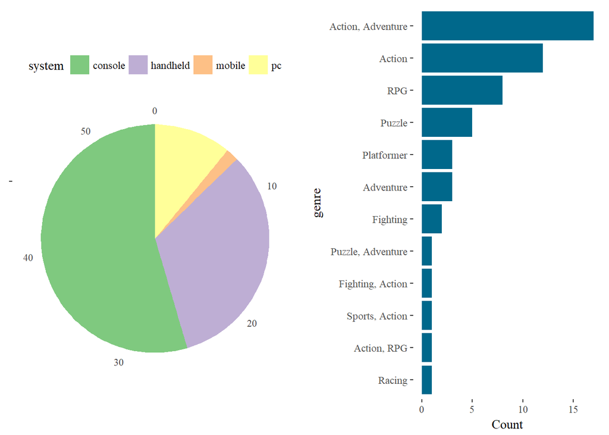

```r
masterpiece <- filter(ign, score_phrase == "Masterpiece")
plot1 <- masterpiece %>%
    group_by(system) %>%
    summarize(count = n()) %>%
    ggplot(aes(x = "", y = count, fill = system)) +
    geom_col(width = 1) +
    coord_polar("y", start = 0) +
    scale_fill_brewer(palette = "Accent") +
    theme_tufte() +
    theme(axis.title.x = element_blank(), axis.title.y = element_blank(),
          legend.position = "top")
plot2 <- masterpiece %>%
    mutate(genre = factor(genre,
                          levels = names(sort(table(genre), decreasing=FALSE)))) %>%
    group_by(genre) %>%
    summarize(count = n()) %>%
    ggplot(aes(x = genre, y = count)) +
    geom_col(fill = "deepskyblue4") +
    coord_flip() +
    theme_tufte() +
    labs(y = "Count")
grid.arrange(plot1, plot2, nrow = 1)
```

It is quite surprising how many masterpieces hand held system has given its limited titles. Perhaps nostalgia has a big influence on this number. Action, Adventure and RPG occupy many of the slot while there is not a single Strategy masterpiece!

Lets see if wordcloud offer us anymore insight

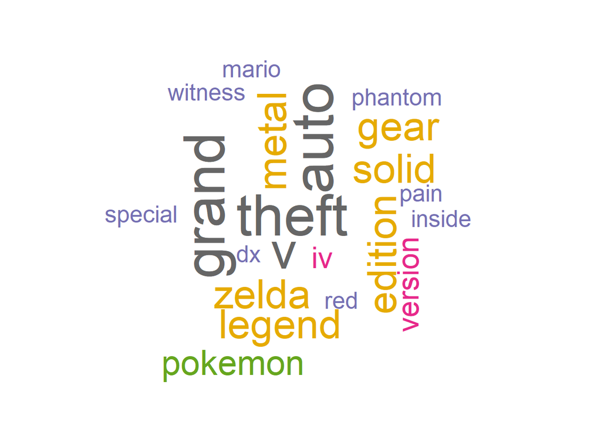

```r
title_masterpiece <- concatenate(masterpiece$title)

clean <- function(x){
    x <- replace_contraction(x)
    x <- removePunctuation(x)
    x <- tolower(x)
    x <- removeWords(x, stopwords("en"))
}

title_masterpiece <- clean(title_masterpiece)
uni_gram <- ngram(title_masterpiece, n = 1)
freq <- get.phrasetable(uni_gram)

wordcloud(freq$ngrams, freq$freq, random.order=FALSE, rot.per=0.35,
          colors=brewer.pal(8, "Dark2"))
```

Such a big impression by grand theft auto franchise! Pokemon and Metal Gear Solid are also seen.

Finally, lets expand our word clouds to the full dataset.

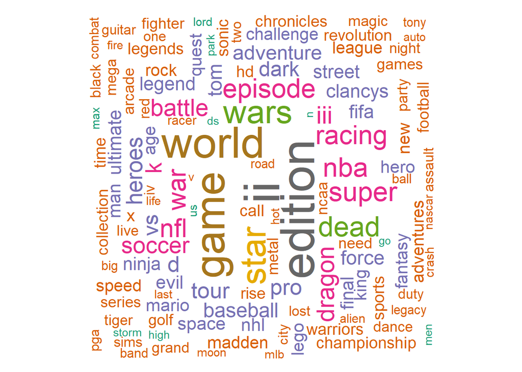

```r
title <- concatenate(ign$title)

clean2 <- function(x){
    x <- removeNumbers(x)
    x <- removeWords(x, c("game"))
}

title <- clean2(title)
title <- clean(title)
uni_gram <- ngram(title, n = 1)
freq <- get.phrasetable(uni_gram)

wordcloud(freq$ngrams, freq$freq, random.order=FALSE, rot.per=0.35,
          colors=brewer.pal(8, "Dark2"), max.words = 200)
```

Now we can see a more diverse set of words. ii, iii and edition signify an abundant of sequels. Wars, dead, world show up due to a big number of Action, RPG genres. Episode also appears quite often (perhaps the Star War franchise). In fact, lets count how many game titles about Star Wars.

```r
index <- grepl(".*[Ss]tar [Ww]ar.*", x = ign$title)
print(paste("There are", sum(index), "Star War related titles"))
```

```
## [1] "There are 161 Star War related titles"
```

```r
head(ign$title[index], 20)
```

```
##  [1] "Angry Birds Star Wars"
##  [2] "Star Wars: Dark Forces"
##  [3] "Star Wars: Shadows of the Empire"
##  [4] "Star Wars: Masters of Teras Kasi"
##  [5] "Star Wars: Rogue Squadron"
##  [6] "Star Wars: Rogue Squadron 3D"
##  [7] "Star Wars: X-Wing Alliance"
##  [8] "Star Wars: Episode I: The Phantom Menace"
##  [9] "Star Wars: Episode I: Racer"
## [10] "Star Wars: Episode I: Racer"
## [11] "Star Wars: Episode I: The Phantom Menace"
## [12] "Star Wars: Episode I: Racer"
## [13] "Star Wars: Pit Droids"
## [14] "Star Wars: Yoda Stories"
## [15] "Star Wars: Force Commander"
## [16] "Star Wars: Episode I: Jedi Power Battles"
## [17] "Star Wars: Episode I: Racer"
## [18] "Star Wars: Episode I: Jedi Power Battles"
## [19] "Star Wars Demolition"
## [20] "Star Wars Demolition"
```

## Final notes

The dataset is quite simple and clean with only 9 variables. While the abundant of data shows us many properties of video games of the last two decades, the lack of features mean we cannot dive deeper than exploratory data analysis.

Nevertheless, it is a fun exercise to try out various plotting techniques and a nostalgia dose for who has been playing video games for over a decade. The last question we will answer one last question: Which is the oldest game in the dataset? (and maybe in history)

```r
ign %>% filter(release_year == min(release_year)) %>% select(title)
```

```
## # A tibble: 1 x 1
##                                                title
##                                                <chr>
## 1 The Walking Dead: The Game -- Episode 1: A New Day
```

Now that is a surprise!